# Regional Growth and Interregional Connections

Module 2 · Student reader · ECON 463

Author

Jude Bayham

# 1 Opening question

## 1.1 Why do regions grow differently?

Module 1 explained why a firm might choose one site and why firms might cluster. Its numerical examples held output and revenue fixed. We now relax that restriction: customers change their purchases, firms invest, people move, and productivity changes. A place with the lowest delivered cost today need not have the fastest growth tomorrow. Its future also depends on demand for its products, available workers and capital, and the responses of connected places.

The central question is **why regions grow differently, and how changes spread between them**. A useful explanation identifies an initiating change, the decisions it changes, and the constraints that limit adjustment. For example, stronger demand for a region’s manufactured products can increase factory orders and local supplier purchases. Whether this raises employment or mainly raises prices depends on spare capacity, labor availability, and the time allowed for adjustment. Calling a place a “growth region” does not explain these mechanisms.

By the end of this module, you should be able to compare explanations involving productivity, industrial structure, market access, trade, and migration (**LO3**). You should also be able to explain when the agglomeration mechanisms from Module 1 reinforce growth, and when congestion or other costs limit that process (**LO2**). Each example asks the same question: **What mechanism explains this result, and which assumption would change your conclusion?**

## 1.2 How to use this reader

The five lecture questions guide the examples. First choose a region. Then ask what sets growth in motion, how export orders reach other industries, how a road changes trade and migration, and what helps one region catch up with another. River and Harbor are fictional regions. The examples use illustrative currency units (CU). The optional festival-program exercise at the end brings the boundary and income calculations together.

Work through the arithmetic before looking at the answers. You need ratios, percentage changes, and a linear equation in one unknown. No matrix algebra, regression, or optimizer is required. The baseline for a percentage change is always the initial value: $100(z_1/z_0-1)$. The periods in Example 1 are two comparable observations, not necessarily consecutive years, so changes are **not annual growth rates**.

Read Hoover and Giarratani (2020), Chapter 11, “How Regions Develop,” from the opening through §11.6, “Interregional Convergence” (printed pp. 217–239, PDF pp. 218–240). The assignment spans 23 pages. Stop at the §11.7 heading on the last page. The opening trends motivate the chapter’s question about why places grow at different rates. As you read §11.3.2, trace how a new order affects purchases from suppliers. Module 6 returns to the calculations.

# 2 Growth, development, and structural change

## 2.1 Which region are we studying?

A **region** groups places according to a stated rule. A district boundary makes sense for a question about district taxes. A rice-growing belt groups places with similar growing conditions. For a question about access to jobs, a region might instead include several districts connected by regular commuting.

**Try the bakery example.** A bakery in Region A pays a baker who lives in Region B and buys flour from a mill outside both regions. On paper, draw an arrow from the bakery to the baker and another from the bakery to the mill. Label each arrow with what the bakery pays for. Draw a boundary around A. Then widen it to include B, keeping the bakery, the baker, and the mill in place. Which payment changes classification?

With A alone, both the wage and the flour payment cross the boundary. With A and B together, the wage stays inside the region because the baker lives there. The flour payment still leaves. The bakery produces its bread in A under either definition. What changes is whether the worker who earns the wage is a resident of the region we are studying. Once you choose a boundary for a growth comparison, use it in both periods.

## 2.2 Choose an outcome before explaining it

Regional **growth** usually refers to an increase in a specified quantity: real output, employment, population, or income. These outcomes can move differently. A region can produce more because it has more workers even if output per worker is unchanged. A region can become more productive while employment falls if production requires fewer workers and demand does not expand enough to absorb them. Always name the measure before describing a place as successful or declining.

Regional **development** is broader. It can involve productive capabilities, access to services, health, environmental quality, and opportunities available to residents. Higher real output can support these improvements, but it is not a complete measure of them. An industrial expansion could increase output and employment while exposing nearby households to pollution. A production measure alone does not tell us whether the affected households are better off.

We use **real value added** as our production measure: the value of output less purchased intermediate inputs, measured at common prices. For producer $i$, write this contribution as $\mathrm{VA}_i$. Regional output is $Y=\sum_i\mathrm{VA}_i$, summing over producers inside the boundary. A bakery subtracts the flour it buys when calculating its contribution. If the mill also operates inside the region, its own value added enters the sum separately. This counts each stage of local production once. “Real” means that a price increase alone does not register as additional production. Module 3 will address how actual datasets define and measure these quantities. For now, all regions and periods use consistent definitions and prices.

Let $Y$ be real value added, $L$ be employment measured in workers, and $N$ be population. A useful accounting identity is

$$Y=\frac{Y}{L}\,L,
\qquad
\frac{Y}{N}=\frac{Y}{L}\frac{L}{N}.$$

Here $Y/L$ is average labor productivity and $L/N$ is employment relative to the entire population. The latter is **not** the employment rate among working-age people or one minus the unemployment rate. The identity helps organize a comparison; it does not establish what caused productivity or employment to change. Productivity can reflect capital, technology, skills, or the mix of industries and workers.

## 2.3 Example 1: River and Harbor

Both regions begin with 1,000 residents and 500 employed workers. They differ in initial production and subsequent growth. Assume no cross-boundary commuting in this small example so that workplace employment and resident employment coincide.

Table 1: Example 1: synthetic regional observations. Value added is real CU per period.

| Region | Period | Real output (CU) | Residents | Workers |
| --- | --- | --- | --- | --- |
| River | 0 | 10000 | 1000 | 500 |
| River | 1 | 13200 | 1200 | 600 |
| Harbor | 0 | 15000 | 1000 | 500 |
| Harbor | 1 | 16800 | 1050 | 525 |

River’s output grows from 10,000 to 13,200 CU, an increase of 32%. Harbor’s grows from 15,000 to 16,800 CU, an increase of 12%. On this measure, River grows faster. But River’s population also grows by 20%, compared with Harbor’s 5%. To find output per resident, divide each period’s real output by that period’s resident count. For River, $10{,}000/1{,}000=10$ and $13{,}200/1{,}200=11$ CU per resident. Try Harbor before checking: $15{,}000/1{,}000=15$ and $16{,}800/1{,}050=16$. Each region gained 1 CU per resident. Dividing the gain by the starting level gives $1/10=10\%$ for River and $1/15\approx6.7\%$ for Harbor.

You can check the result using the growth factors. Dividing River’s output growth factor by its population growth factor gives $1.32/1.20=1.10$. If output and population had both risen 10%, their ratio would have been $1.10/1.10=1$, leaving output per resident unchanged.

| Region | Period | CU/worker | Workers/resident | CU/resident |
| --- | --- | --- | --- | --- |
| River | 0 | 20 | 0.5 | 10 |
| River | 1 | 22 | 0.5 | 11 |
| Harbor | 0 | 30 | 0.5 | 15 |
| Harbor | 1 | 32 | 0.5 | 16 |

Harbor finishes at a higher level of output per resident, even though River grew faster. To recover River’s final 11 CU per resident from the worker data, multiply 22 CU per worker by 0.5 workers per resident. The worker units cancel.

River’s output growth combines a 10% increase in productivity with a 20% increase in employment. The exact calculation is $1.10\times1.20-1=0.32$. Adding the two percentages gives 30%, which misses their interaction. Harbor’s calculation is $(32/30)\times(525/500)-1=0.12$. In both regions $L/N$ stays at 0.5, so per-resident production grows at the same percentage rate as productivity.

Even with this careful arithmetic, $Y/N$ is not resident disposable income or welfare. Some value added may accrue to owners elsewhere. Actual commuters can produce in one region and live in another. Housing costs, amenities, leisure, and the distribution of income also matter. The table describes production and population; it cannot identify every resident’s gain.

## 2.4 Structural change can raise an average

Suppose River initially has 300 workers in agriculture producing 10 CU per worker and 200 in other activities producing 35 CU per worker. Total value added is $300(10)+200(35)=10{,}000$, matching River’s initial total. Now move 100 workers from agriculture to other activities, holding total employment and both sector productivities fixed.

Table 2: Example 1 extension: a separate reallocation counterfactual, not River’s observed period 1.

| Scenario | Sector | Workers | CU/worker |
| --- | --- | --- | --- |
| Baseline | Agriculture | 300 | 10 |
| Baseline | Other | 200 | 35 |
| Reallocation | Agriculture | 200 | 10 |
| Reallocation | Other | 300 | 35 |

Value added becomes $200(10)+300(35)=12{,}500$. Average productivity rises from 20 to 25 CU per worker, or 25%, even though neither sector becomes more productive. Aggregate productivity is a weighted average of sector productivity, with employment shares as the weights:

$$\frac{Y}{L}=\sum_s\frac{L_s}{L}\frac{Y_s}{L_s}.$$

In the two-sector notation from class, let $s$ be the share in other activities. The average is $(1-s)10+s(35)$. The move raises $s$ from $200/500=0.4$ to $300/500=0.6$. The change in the regional average is therefore $(0.6-0.4)(35-10)=5$ CU per worker. This gives a second way to check the calculation.

This is a separate counterfactual starting from River’s baseline. It does not decompose the actual change to 13,200. In real data, both within-sector productivity and employment shares may change. Module 3 will develop formal descriptions of industrial structure and change; we do not need shift-share formulas here.

Nor does a sector productivity gap prove that moving any particular worker creates 25 CU of additional production. The example assumes that destination employers can absorb the workers at the stated productivity, that workers have the needed skills, and that other inputs are available. Differences in average productivity can reflect capital intensity or worker selection. Retraining costs, lost agricultural output, and the demand for additional production belong in a real causal argument. The arithmetic illustrates a possible composition effect, not a policy impact estimate.

# 3 Demand, supply, and local feedback

## 3.1 Distinguish the initiating change from its transmission

A **demand explanation** begins with buyers wanting more of a region’s output: a new export order, increased tourism, or higher spending by an outside customer. It then traces purchases, production, and incomes. A **supply explanation** begins with a change in productive capacity or cost: better skills, new equipment, improved logistics, or access to an input. It then asks whether firms can sell additional output and how prices and employment respond. A complete explanation often uses both.

## 3.2 The economic base: basic and nonbasic activity

Begin by choosing a region and drawing its boundary. In the **export-base model**, the **economic base** consists of activities that sell goods or services to customers outside that region. These sales bring in purchasing power. The model then asks how that outside demand supports production, employment, and income within the region. This is a particular explanation of regional growth, not a claim that all improvements must originate outside the region.

**Basic activity**, also called **base activity**, serves outside customers under this export-sales definition. River’s rice sales to Harbor are basic activity for River. The **basic sector** is the collection of those activities. A **base industry** is an industry with activity serving those outside markets; the label need not describe every sale by every establishment in that industry.

**Nonbasic activity**, also called **non-base** or **local-serving activity**, serves customers within the region under the same definition. Haircuts sold to River residents provide a straightforward example. In the simplest export-base model, basic activity responds to outside demand and nonbasic activity responds to local demand. This is an assumption about how demand changes, not something proved by classifying a sale. **Nonbasic does not mean unnecessary, unproductive, or low value.** Schools, repair services, and health care can improve residents’ lives and support the region’s productive capacity.

### 3.2.1 The market served matters more than the industry name

An **export** crosses the chosen regional boundary, not necessarily a national border. River’s sales to Harbor count even when both places belong to the same country. Nor must a physical product leave River. A visitor can come to River and purchase a meal, a hotel stay, or another service. Those visitor sales are exports for River. Manufacturing is therefore not automatically basic, and services are not automatically nonbasic.

For practice, compare a River hotel serving outside visitors with a software firm serving only River businesses. Under the export-sales definition, the hotel’s visitor sales are basic and the software firm’s local sales are nonbasic. The distinction depends on customers, not the sophistication of the product. The software firm may still support exporting clients indirectly, a connection considered below.

One establishment can serve both markets. Suppose a River restaurant sells 100 CU of meals, of which 80 CU go to outside visitors and 20 CU to River residents. Total sales are $S=S_E+S_L=80+20=100$ CU, where $E$ denotes export sales and $L$ denotes sales to local customers. Divide export revenue by total revenue to get the basic share, $S_E/S=80/100=0.80$. The remaining 20% of sales are nonbasic. These are **sales shares**, not necessarily employment or value-added shares. Allocating workers or income using the same percentages would require additional assumptions. If all visitors came from Harbor, their purchases would be exports for River but internal sales for a combined River–Harbor region.

Hoover and Giarratani warn against assigning whole industries to the export or nonexport category without investigating their actual markets (Hoover and Giarratani 2020, 225). In practice, customer and shipment information can help. Location quotients provide an indirect approach, but they do not directly observe exports; Module 3 develops their interpretation and limitations.

### 3.2.2 Local suppliers and the limits of the classification

Suppose a River repair shop serves a local rice processor that exports its product. The repair shop’s immediate customer is local, but the demand for repairs is **indirectly tied to exports**. Some economic-base studies include such indirect export activities in the base. A classification based on direct sales and one based on the ultimate source of demand can therefore produce different labels. State the rule before interpreting a base-industry measure. The reading illustrates this issue with local suppliers to exporting producers (Hoover and Giarratani 2020, 226).

The reading also qualifies the export-base story: import substitution and interregionally traded activities complicate a simple exporter/local-service split, and exports alone cannot explain all growth (Hoover and Giarratani 2020, 226–27). Local services can make exporting possible, while imported equipment and inputs can improve productivity. Replacing an import with a local product can retain spending, but that does not establish a welfare gain if the local product costs more or performs worse. Treat the vocabulary as a way to organize a demand mechanism, not as a ranking of which industries deserve support.

## 3.3 From the base to local feedback

Now trace a change rather than just classify activity. Outside buyers place more orders with River’s processor. The processor purchases inputs and pays workers; local suppliers and households then make further purchases. Some expenditure goes outside River or does not generate another local round. A **multiplier** summarizes the total response to a specified initial change under stated assumptions. Do not count a supplier response both as part of the initial base shock and again as a separate subsequent effect.

To sketch the rice order from class, draw Harbor’s buyer paying River’s processor. Draw two arrows out of the processor. One goes to a repair shop for its services. The other goes to workers for their labor. Extend the workers’ branch to the grocer where they spend some of their pay. The repair shop gains a customer directly from the processor’s production decision. The grocer gains sales when households decide to spend. If the repair shop buys parts from Harbor, mark that payment crossing River’s boundary.

The restaurant’s 100 CU of sales and its 80% basic share are not the inputs to the income calculation below. Sales, income, and employment are different quantities, and the basic sales share is not the local-income feedback coefficient. For the distinction between demand and supply, see Hoover and Giarratani (2020), §11.2, pp. 223–224. For economic-base vocabulary and its qualifications, read §11.3.1, pp. 224–227. The input-output machinery in §11.3.2 belongs in Module 6.

## 3.4 Example 2: an export-demand shock

**Find the income that starts the first round.** The slide starts with a 100-CU gain for River residents. One way this can happen is for Harbor to pay 140 CU for processed rice. Suppose River’s processor pays 40 CU for packaging from outside the region and the balance goes to River residents as wages and profits. The direct gain is $\Delta X=140-40=100$ CU.

**Follow one round of spending.** Households spend a share $s=0.80$ of each additional CU at River businesses. A share $v=0.75$ of those sales becomes income for River residents. Starting with 100 CU, households spend $100(0.80)=80$ CU locally. That generates $80(0.75)=60$ CU of new resident income. The feedback coefficient is $b=sv=0.60$. In the next round, 60 CU supports 48 CU of spending and 36 CU of new income. Keep spending and income in separate columns if you work this by hand.

**Add the income rounds.** Let $\Delta I$ be the total change in resident income. The direct gain and each later round form a geometric series:

$$\Delta I=\Delta X+b\Delta X+b^2\Delta X+\cdots.$$

Multiplying by $b$ shifts the series forward one round. The difference between the two series is exactly the first term, so $(1-b)\Delta I=\Delta X$. With $0\leq b<1$, the income multiplier is $m=1/(1-b)$. For River, $m=1/(1-0.60)=2.5$ and the total gain is $100(2.5)=250$ CU. Of that total, $250-100=150$ CU comes from later rounds. Adding the 80 CU of shop sales to the 60 CU of income it generates would count part of the same transaction twice.

Read the table across each row. Round 0 is the initial income gain. At the end of round 1, cumulative income is $100+60=160$ CU. Each row tracks one more round of payments within the same scenario.

| Round | Additional income (CU) | Cumulative income (CU) |
| --- | --- | --- |
| 0 | 100.00 | 100.00 |
| 1 | 60.00 | 160.00 |
| 2 | 36.00 | 196.00 |
| 3 | 21.60 | 217.60 |
| 4 | 12.96 | 230.56 |

The sum remains finite because $0\leq b<1$. Each additional round is smaller. At $b=0$, total income changes only by the original 100 CU. As $b$ approaches one, the formula becomes very sensitive; this should prompt scrutiny of the assumptions, not a claim of unlimited productive capacity. A pure feedback model with $b=1$ has no finite solution for a nonzero shock.

## 3.5 Change the local feedback assumption

Now suppose more of the additional spending leaves the region, lowering $b$ to 0.40. The same direct shock produces $100/(1-0.40)=166.7$ CU. The initial income addition is unchanged; subsequent local rounds are smaller. The difference of 83.3 CU comes entirely from the changed feedback assumption.

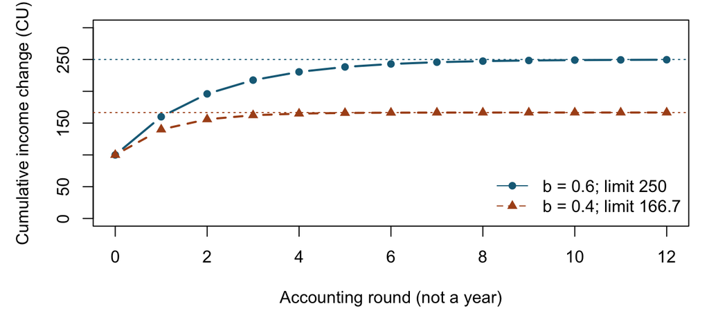

Figure 1: Example 2: cumulative income responses to the same synthetic 100-CU shock.

An import is a leakage **from this region’s income feedback**, but it is revenue for a producer somewhere else and may provide a better or cheaper input. A larger local multiplier is therefore not automatically a welfare improvement. Requiring expensive local purchases could retain more spending locally while reducing purchasing power or productivity. We have not calculated those effects.

The regional boundary matters too. A purchase from a nearby district is an import for a narrow district boundary and an internal transaction for a combined region. One cannot compare two multipliers without comparing their geographic scope, income definitions, and assumptions. Module 3 formalizes boundary choices. Module 6 traces sector purchases and distinguishes output, value added, and income more carefully.

## 3.6 What this model leaves out

The calculation holds prices, the feedback coefficient, and production relationships fixed. It assumes enough available labor and capacity to meet the additional demand without displacing other production. It does not model investment decisions, technology, migration, housing, or an ongoing productivity trend. A one-time shift in the level of income is not a theory of sustained growth in income per person.

If factories already operate at capacity, the first response may include higher prices, longer delivery times, imports, or displacement of other customers. If workers arrive later, employment and housing demand can change together. Investment can expand capacity, but firms need expected returns, financing, and time. These mechanisms determine whether the demand-driven calculation is a useful approximation for the stated horizon.

Under the model’s unchanged assumptions, a negative 100-CU shock gives a negative 250-CU total response at $b=0.60$. Actual expansions and contractions need not be symmetric: layoffs, business exit, unused buildings, and moving costs can make a decline persistent. The formula supplies a conditional comparison, not evidence that a particular event caused the observed change.

# 4 Market access and trade

## 4.1 Example 3: a corridor between River and Harbor

Consider a hypothetical transport improvement connecting an agricultural region, River, with a manufacturing and service center, Harbor. This is a scenario for tracing mechanisms, separate from Example 1’s period comparison. We have no estimated effect of the corridor on either region’s production. The counterfactual is the same economy over the same horizon **without the transport improvement**, holding other initiating changes fixed.

Better **market access** means reaching customers or suppliers at lower generalized cost, including freight charges, travel time, spoilage, and reliability. River’s farmers may reach Harbor’s buyers more cheaply. Harbor’s manufacturers may reach River’s customers more cheaply. Firms in both regions may obtain inputs at lower delivered prices. The same connection also exposes local producers to more outside competition.

**Which seller supplies the grain?** Hold grain quality and seller prices fixed. Harbor buyers can pay $p_H=11$ CU per unit locally. River grain costs $p_R=8$ at the source plus freight $t$ per unit. Before the road improves, River’s delivered price is $8+4=12$ CU, so the buyer chooses Harbor. Afterward it is $8+2=10$ CU, so the buyer chooses River. To find the switching point, set $p_R+t=p_H$. At $t^*=11-8=3$ CU the buyer is indifferent. Below 3 CU the River seller can undercut the Harbor seller. The buyer saves 1 CU relative to the 11 CU they actually paid before the improvement.

A seller’s gain is not simply the entire freight saving multiplied by existing shipments. Prices may adjust, customers may switch suppliers, and shipment volumes may change. The distribution of the saving depends on competition and bargaining as well as technology. Our Module 1 location calculation held revenue fixed; this scenario explicitly asks what happens when customer access and competition change revenue too.

Trade allows specialization when the gains exceed trade costs. Comparative advantage concerns **relative opportunity costs**, so a place need not be the most productive at everything to participate in mutually useful exchange. Larger markets can also support production at a more efficient scale or specialized services. Yet a region’s increased specialization can make its income more sensitive to an industry-specific downturn. Diversity is useful when activities face different shocks; merely counting more industries does not guarantee resilience.

## 4.2 Benefits can cross boundaries in several ways

Trace at least four connections. First, orders from Harbor may raise demand for River’s crops and services. Second, cheaper imported machinery or inputs may improve River’s productivity. Third, workers may commute or migrate in response to job opportunities. Fourth, repeated interaction can spread knowledge about production, quality, or logistics. These are distinct mechanisms and need different evidence.

Purchased services and supplier revenue are market transactions. A knowledge spillover occurs when useful knowledge benefits others without the originator capturing the full return. A corridor’s effect on supplier sales does not, by itself, establish a knowledge spillover. Evidence might include adoption of a technique after contact, but even that pattern requires consideration of shared demand changes or selection of more productive firms into the corridor.

Transport improvements need not disperse production evenly. A large Harbor producer may now serve River from one plant, saving fixed costs as in Module 1. Alternatively, lower freight costs may allow a River producer to serve Harbor while taking advantage of cheaper land or inputs. The direction depends on scale economies, initial costs, market size, and local constraints. **Cheaper transport strengthens connections; it does not guarantee that every place gains jobs.** See Hoover and Giarratani (2020), §11.5, pp. 234–236, for trade and factor movements.

# 5 Migration, capital, and rural–urban connections

## 5.1 Compare opportunities after costs

A wage gap is one reason to consider moving, but a household compares opportunities after housing, commuting, moving costs, risk, and amenities. A higher nominal wage can accompany higher living costs. Some households cannot finance a move; others have location-specific skills, family obligations, or a preference for their current community. Workers therefore need not move immediately until nominal wages equalize.

A road may make daily commuting feasible for someone who wants to keep their home. For a worker considering relocation, let $d=(w_H-c_H)-(w_R-c_R)$ be the annual gain in the remaining budget after housing and commuting costs, and let $F$ be the one-time cost of moving. Over $T$ years the gain is $Td-F$. When $d>0$, dividing $F$ by $d$ tells us how many years of gains pay for the move.

In Example 3, suppose an annual wage is 100 CU in River and 140 CU in Harbor. Annual housing and commuting costs are 40 and 70 CU. The remaining budget is 60 CU in River and 70 CU in Harbor. A one-time moving cost of 15 CU makes the first-year destination budget 55 CU, compared with 60 from staying. The first-year gain is negative 5 CU. The recurring advantage is 10 CU per year, so recovering the 15 CU moving cost takes $15/10=1.5$ years if earnings accrue evenly. A worker staying two full years comes out 5 CU ahead.

Table 3: Example 3: illustrative budgets with constant wages and costs; no discounting.

| Year | Stay (CU) | Move (CU) | Cumulative gain (CU) |
| --- | --- | --- | --- |
| 1 | 60 | 55 | -5 |
| 2 | 60 | 70 | 5 |
| 3 | 60 | 70 | 15 |

Over three years, the undiscounted gain is $3(70-60)-15=15$ CU. With a one-year horizon, the move loses 5 CU. If Harbor’s annual housing and commuting costs rise to 85 CU, its recurring remaining budget becomes 55 CU, and the three-year gain becomes negative 30 CU. The conclusion changes without any change in the nominal wage offer.

This budget assumes certain employment, unchanged wages and costs, identical other expenses and amenities, and no discounting. It is not a solved spatial equilibrium or a full welfare measure. A household may need credit to cover the initial expense even if the cumulative gain is positive. Different workers can face different job prospects and costs. Module 4 will connect household and firm choices to endogenous wages, rents, and population.

## 5.2 Both origins and destinations adjust

An inflow of workers can help Harbor firms expand and enlarge demand for shops and services. Holding labor demand fixed, additional labor supply tends to put downward pressure on wages, but firms may also invest and raise labor demand. Housing demand can raise rents if supply is slow to respond. Congestion can erode benefits. The final wage response is therefore not determined by the direction of migration alone.

River can lose workers and consumers, which may reduce production and local demand. But migrants may send remittances, return with skills, or establish business links. A smaller workforce may raise remaining workers’ bargaining opportunities or wages under some conditions. Whether these effects offset the loss depends on the workers who leave, the substitutability of labor, and what happens to investment and demand.

Capital can also flow toward expected returns, complementing or substituting for labor. A new processing facility may increase demand for local workers and farm output; a labor-saving machine may reduce labor required per unit. Expanding output can offset that reduction. Existing buildings and infrastructure cannot simply move between regions like financial claims. The speed and reversibility of adjustment matter when interpreting regional decline.

Rural–urban connections include food and input purchases, commuting, seasonal movement, remittances, service access, and knowledge. A city boundary can split a connected labor and product market. In the corridor scenario, ask separately about River farmers, River shop owners, Harbor renters, and property owners. Aggregate growth in either region can coexist with losses for some groups. For additional migration detail, consult Hoover and Giarratani (2020), §10.3, pp. 197–208; for cities and development, use §11.7, pp. 239–242 selectively.

# 6 Convergence and divergence

## 6.1 Example 1 revisited: what kind of convergence?

River’s production per resident grows faster than Harbor’s, but the absolute difference remains 5 CU: initially $15-10=5$, subsequently $16-11=5$. The ratio rises from $10/15=0.667$ to $11/16=0.688$. River partially catches up **in relative terms** without closing the absolute gap.

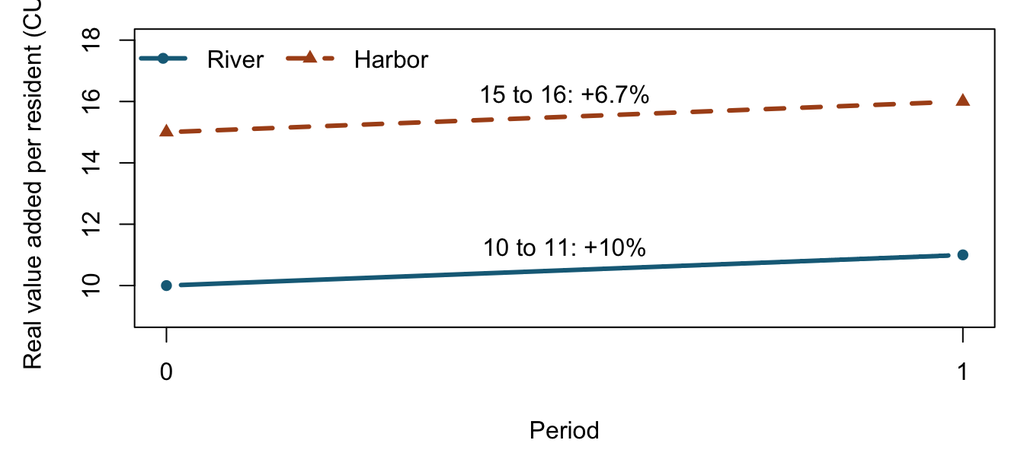

Figure 2: Example 1 revisited: faster percentage growth need not shrink the absolute gap.

Always name the outcome and criterion when claiming convergence. Are production per resident, wages, employment shares, or population growth rates becoming more similar? Are we comparing differences, ratios, or dispersion across many regions? Two regions over two periods illustrate the distinction; they cannot establish a general convergence law.

## 6.2 Forces can reinforce or limit concentration

Convergence can arise when knowledge diffuses, new investment earns attractive returns in a capital-scarce place, or workers move toward better opportunities. These mechanisms depend on access to technology, skills, infrastructure, and institutions. Diminishing returns to one input do not guarantee catch-up if other complementary inputs are missing.

Divergence can arise when expansion supports specialized suppliers and matching, making an already productive region more attractive to firms and workers. This is Module 1’s agglomeration logic applied to a sequence of changes. The reverse can also operate: business exit weakens supplier viability and local demand, making further exit more likely. Historical advantages and sunk investments can matter for the path a region follows.

Neither process is unlimited. Rising rents, congestion, scarce inputs, and competition can offset agglomeration benefits. The balance can differ across industries and time horizons. Labor mobility might reduce differences in comparable workers’ opportunities even while concentrating population in fewer places. The distribution of activity and the distribution of well-being are related questions, not identical ones. Hoover and Giarratani (2020), §11.6, pp. 237–239, presents convergence as something to explain rather than an inevitable outcome.

## 6.3 What would distinguish competing explanations?

Suppose employment rises after a road opens. Possible explanations include cheaper freight, an unrelated demand boom, firms selecting into an already growing corridor, or an accompanying investment program. Before-and-after comparison alone cannot separate them. Ask what would have happened without the road, what other changes occurred, and whether a credible comparison is available. A model can show what follows from assumptions; it cannot supply missing causal evidence simply by producing a precise number.

Useful observations depend on the mechanism. Freight rates, delivery reliability, and shipment destinations speak to access. Establishment output, inputs, and worker composition help interpret productivity. Job offers, rents, and flows of people inform migration. Supplier entry and transactions inform local purchasing; knowledge transfer requires additional evidence. These observations help assess an explanation, but none alone guarantees causal identification. Module 5 returns to the interpretation of spatial evidence.

# 7 Guided practice and synthesis

## 7.1 Practice A: growth versus composition

Using Example 1, calculate River’s output, employment, and productivity growth. Then explain why the percentages do not simply add. **Worked answer:** output rises 32%, employment 20%, and productivity 10%. The exact output factor is $1.20\times1.10=1.32$. The extra two percentage points are the interaction of the two increases.

Next hold total employment at 500 and move 50, rather than 100, workers from agriculture to other activities. **Worked answer:** $250(10)+250(35)=11{,}250$ CU, or 22.5 CU per worker. This is a 12.5% increase from the baseline. Sector productivities do not change. The result depends on the ability to employ the additional workers at 35 CU each, which the arithmetic assumes rather than establishes.

## 7.2 Practice B: trace a smaller shock

Let the direct income addition be 80 CU and $b=0.50$. Predict the first three rounds, the total, and the additional income beyond the direct shock. Then set $b=0.25$ while holding the direct shock fixed.

**Worked answer:** the first rounds are 80, 40, and 20 CU. Total income changes by $80/(1-0.50)=160$ CU; 80 CU is additional to the direct shock. With $b=0.25$, the total is approximately 106.7 CU and the additional amount is 26.7 CU. More of the feedback now leaves the region. This is not proof that restricting imports would improve welfare: the model omits their price and productivity benefits.

## 7.3 Practice C: compare two corridor explanations

Write four sentences about Example 3: (1) state the corridor/no-corridor comparison; (2) trace one benefit to River through trade; (3) identify one possible loss or cost in either region; and (4) identify evidence that would help distinguish your mechanism from another explanation.

**One worked response:** Compared with the same period without the corridor, lower delivery costs could increase River farmers’ sales to Harbor. Higher farm income could support local purchases, with the size of the response depending on capacity and local sourcing. River retailers could lose customers to Harbor competitors, while Harbor renters could face higher housing costs if workers move there. Changes in freight costs, shipment destinations, retailer sales, migration, and rents would help assess these channels, although a credible counterfactual is still needed for a causal estimate.

**Check the household decision.** If Harbor’s annual housing and commuting costs rise to 85 CU, the annual gain changes to $(140-85)-(100-40)=-5$ CU. Over three years the worker would give up 15 CU in recurring income after costs and pay 15 CU to move. Staying leaves the worker 30 CU ahead.

## 7.4 Optional practice: a festival orders printed programs

### 7.4.1 Follow the money across the boundary

A festival in Region B buys programs from a printer in Region A. The printer pays a bindery in A, a paper supplier outside both regions, and an employee who lives in B. The employee buys a meal at a café in B. Sketch the arrows from payer to recipient. Which payments cross A’s boundary? What changes if the region includes both A and B?

**Worked explanation.** The festival’s payment enters A, making the program sale an export. The printer’s payment to the bindery stays in A. The bindery can therefore gain business from the export order even if it serves only local customers. The printer’s payments to the paper supplier and commuter leave A. The café purchase takes place in B. Enlarge the boundary to A and B together and trace the same arrows again. Now only the paper payment crosses the boundary.

### 7.4.2 Calculate the initial income from each order

Suppose the festival can order either 400 or 600 CU of programs. The local bindery reaches capacity filling the smaller order. For the larger order the printer hires a second bindery outside A. The local bindery spends 40% of its fee on imported materials, and the rest goes to A’s residents. Assume payments outside A stay there.

| Printer’s payment (CU) | 400 CU order | 600 CU order |
| --- | --- | --- |
| Wages to residents of A | 120 | 180 |
| Wages to commuters from B | 80 | 120 |
| Fee to the bindery in A | 100 | 100 |
| Fee to a bindery outside A | 0 | 50 |
| Paper from outside A | 100 | 150 |

Before calculating a multiplier, mark the payments that become residents’ income. The commuters live in B. The local bindery earns a fee of 100 CU under either order, of which $100(1-0.40)=60$ CU reaches A’s residents. Adding their wages gives **180 CU** under the smaller order ($120+60$) and **240 CU** under the larger order ($180+60$). A quick check is to add all five payments in each column. They exhaust the order revenue, so adding the printer’s sales again would double count it.

### 7.4.3 Compare total income and income per 100 CU of sales

In this exercise households spend 80% of each additional CU locally, and half of local sales becomes resident income. Start with 100 CU and follow one round: 80 CU of local purchases yields 40 CU of income. Thus $b=0.80(0.50)=0.40$ and $m=1/(1-0.40)=5/3$. Apply the multiplier to the initial **resident income** calculated above.

| Result | 400 CU order | 600 CU order |
| --- | --- | --- |
| Total resident income (CU) | $180(5/3)=300$ | $240(5/3)=400$ |
| Resident income per 100 CU of sales | $100(300/400)=75$ | $100(400/600)\approx66.7$ |

The larger order generates more total income. The smaller order generates more income per 100 CU of sales. The local bindery has no spare capacity for the extra work, so some of the larger order pays a bindery elsewhere. The share of order revenue that initially reaches A’s residents falls from $180/400=45\%$ to $240/600=40\%$. Both initial gains face the same subsequent spending pattern and income multiplier.

## 7.5 Carry forward

For Exam 1, practice explaining mechanisms, distinguishing levels from growth rates, calculating simple ratios and feedback effects, and identifying an assumption that could reverse a conclusion. These exercises prepare you for PS 1, where you will show your calculations and explain your results. See the course schedule for the PS 1 deadline.

Module 3 asks how to choose regional boundaries and comparable data, then measure industrial structure in R. Module 4 develops wage, rent, and population adjustment. Module 6 extends demand transmission to a system of industries; Module 7 introduces additional behavioral and resource constraints. The common thread is to define the outcome and counterfactual, trace the mechanism, and state what the calculation leaves out.

# 8 Reading guide and references

The following page numbers use the local fourth-edition web version of Hoover and Giarratani (updated 2020). Add one to the printed page number to obtain the PDF page. Its historical examples illustrate arguments; they are not current regional statistics.

| Purpose | Selection | Printed pages | PDF pages |
| --- | --- | --- | --- |
| Assigned reading | §§11.1–11.6 | 217–239 | 218–240 |
| Supporting: migration detail | §10.3 | 197–208 | 198–209 |
| Optional: cities and regional development | §11.7 | 239–242 | 240–243 |

As you read from the beginning of the chapter through §11.6, ask what initiates change, how it spreads, and what limits or reverses it. The income-feedback calculation and numerical tables in this reader use synthetic values, not empirical estimates from the text.

Hoover, Edgar M., and Frank Giarratani. 2020. *An Introduction to Regional Economics*. 4th ed. Regional Research Institute, West Virginia University.